# rmANOVA

Esko

01.07.2016

## Dataset

We start with the raw game data from the previous sections.

```r
game.raw <- read.table("kr_gameraw.txt", header=T)
head(game.raw)
```

```
##    player_id age_grp clip_id video_id box_id correctRejection falseAlarm
## 1 2016020202       A     121        0      0            FALSE      FALSE
## 2 2016020202       A     121        0      1            FALSE       TRUE
## 3 2016020202       A     171        1      0            FALSE      FALSE
## 4 2016020202       A     171        1      1             TRUE      FALSE
## 5 2016020202       A     171        1      2             TRUE      FALSE
## 6 2016020202       A     130        2      0            FALSE      FALSE
##    miss   hit gender
## 1 FALSE  TRUE   Mies
## 2 FALSE FALSE   Mies
## 3 FALSE  TRUE   Mies
## 4 FALSE FALSE   Mies
## 5 FALSE FALSE   Mies
## 6 FALSE  TRUE   Mies
```

The data was about learning game, where each player player 30 video clips.

## Question: Did players performance improve while playing the game?

A very straigforward way to examine this question would be to divide the 30 videos clips to three sets, each containing 10 clips. Then we could calculate – that is, aggregate – the Phit value by each set and player.

## Recoding video_id to set

There is variable video_id, which coded the order of the videos from 0 to 29. We can use it to form a new variable set.

```r
# Using a quite easy to understand recode function from package car
require(car)
game.raw$set <- recode(game.raw$video_id, "0:9=1; 10:19=2; 20:29=3")

# Making the same thing with some math and using function floor to round downwards.
# E.g. 7 / 10 = 0.7; floor(0.7) = 0; 0 + 1 = 1
game.raw$set2 <- floor(game.raw$video_id / 10) + 1

# The results are identical. It is up to you which one to use.
game.raw$set == game.raw$set2
```

[output not shown]

[output cut: 204 more lines]

Finally, it is a good to convert set explicitly to ordered factor.

```r
game.raw$set <- ordered(game.raw$set)
```

## Aggregation by player and set

```r
require(plyr)
params <- ddply(game.raw, .(age_grp, player_id, set), summarize,
                  Phit = mean(hit))

head(params)
```

```
##   age_grp  player_id set      Phit
## 1       A 2016020202   1 0.5217391
## 2       A 2016020202   2 0.5357143
## 3       A 2016020202   3 0.5000000
## 4       A 2016020302   1 0.5384615
## 5       A 2016020302   2 0.4615385
## 6       A 2016020302   3 0.5185185
```

We could also include more parameters to the calculation.

```r
params <- ddply(game.raw, .(age_grp, player_id, set), summarize,
                  Phit = mean(hit),
                  PcorrectRejection = mean(correctRejection),
                  accuracy = Phit + PcorrectRejection)
head(params)
```

```
##   age_grp  player_id set      Phit PcorrectRejection  accuracy
## 1       A 2016020202   1 0.5217391         0.2173913 0.7391304
## 2       A 2016020202   2 0.5357143         0.4285714 0.9642857
## 3       A 2016020202   3 0.5000000         0.3928571 0.8928571
## 4       A 2016020302   1 0.5384615         0.4230769 0.9615385
## 5       A 2016020302   2 0.4615385         0.3461538 0.8076923
## 6       A 2016020302   3 0.5185185         0.2962963 0.8148148
```

We calcualte both Phit and PcorrectRejection. Then we calculate accuracy by adding them. This is possible already here, because the variable Phit and PcorrectRejection are created before accuracy.

In order to answer the question, it would be great to make first a plot and then repeated measures ANOVA. In the next section we will use ggplot2 to make some fancier plots, but let’s just stick to the R’s in-built plotting tools.

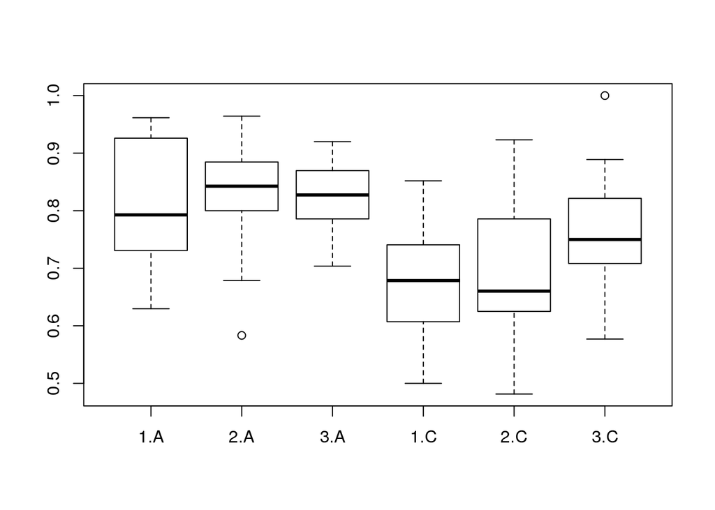

```r
# boxplot
boxplot(accuracy ~ set + age_grp, params)
```

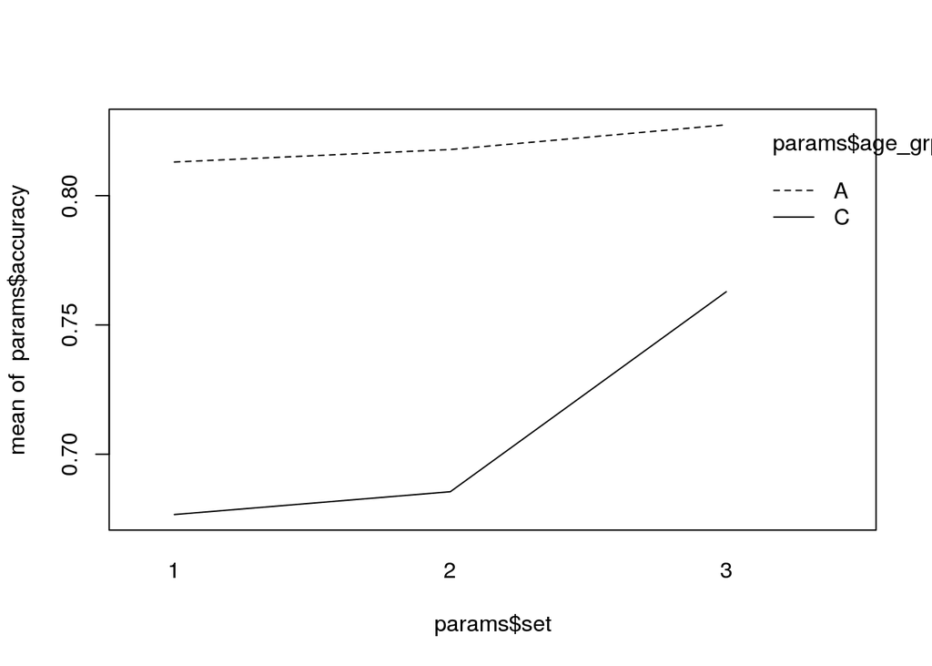

```r
# and this could be used to summarise the effects using means
interaction.plot(params$set, params$age_grp, params$accuracy)
```

## Repeated-measures ANOVA

Making repeated measures ANOVAs in R are is a bit complicated using the in-built functions because you need to understand what you are doing. There I recommed using package ez.

```r
##################################################################################
# Before making anovas with R, set the default contrasts to orthogonal,
# if want to have results comparable to SPSS.
#
# Especially, if you want to use type III Sum of Squares like in SPSS by default,
# you MUST use orthogonal contrasts! Otherwise your results may be wrong.
##################################################################################
options(contrasts = c("contr.sum", "contr.poly"))

require(ez)
fm <- ezANOVA(params,
        dv=accuracy,
        wid=player_id,
        within = .(set),
        between = .(age_grp),
        type=3) # we ask type III Sum of Squares
# If you didn't convert set to a factor, you will run into problems here, because ezANOVA treats it
# numeric and it confuses it

print(fm)
```

```
## $ANOVA
##        Effect DFn DFd         F            p p<.05        ges
## 2     age_grp   1  34 20.529259 6.908823e-05     * 0.19653883
## 3         set   2  68  2.247528 1.134535e-01       0.03783564
## 4 age_grp:set   2  68  1.229412 2.988819e-01       0.02105725
##
## $`Mauchly's Test for Sphericity`
##        Effect         W         p p<.05
## 3         set 0.9031549 0.1862418
## 4 age_grp:set 0.9031549 0.1862418
##
## $`Sphericity Corrections`
##        Effect       GGe     p[GG] p[GG]<.05       HFe     p[HF] p[HF]<.05
## 3         set 0.9117058 0.1186864           0.9606271 0.1157686
## 4 age_grp:set 0.9117058 0.2969190           0.9606271 0.2980754
```

How about the post-hoc testing? Ask the ezANOVA to provide the linear model also, and then feed it to lsmeans.

```r
# I repeat this here: Orthogonal contrasts never forget with type III Sum of Squares!
options(contrasts = c("contr.sum", "contr.poly"))

fm <- ezANOVA(params,
        dv=accuracy,
        wid=player_id,
        within = .(set),
        between = .(age_grp),
        type=3,
        return_aov=T) # get the model
require(lsmeans)
# pairwise post-hocs
lsmeans(fm$aov, pairwise ~ set)
```

```
## NOTE: Results may be misleading due to involvement in interactions
```

```
## $lsmeans
##  set    lsmean         SE     df  lower.CL  upper.CL
##  1   0.7201515 0.01847626 101.82 0.6835032 0.7567999
##  2   0.7269827 0.01847626 101.82 0.6903343 0.7636311
##  3   0.7704448 0.01847626 101.82 0.7337965 0.8070932
##
## Results are averaged over the levels of: age_grp
## Confidence level used: 0.95
##
## $contrasts
##  contrast    estimate         SE df t.ratio p.value
##  1 - 2    -0.00683115 0.02573353 68  -0.265  0.9619
##  1 - 3    -0.05029330 0.02573353 68  -1.954  0.1315
##  2 - 3    -0.04346214 0.02573353 68  -1.689  0.2168
##
## Results are averaged over the levels of: age_grp
## P value adjustment: tukey method for comparing a family of 3 estimates
```

```r
# with summary, you can get e.g. bonferroni or holm adjusted pairwise comparisons
summary(lsmeans(fm$aov, pairwise ~ set), adjust="bonferroni")
```

```
## NOTE: Results may be misleading due to involvement in interactions
```

```
## $lsmeans
##  set    lsmean         SE     df  lower.CL  upper.CL
##  1   0.7201515 0.01847626 101.82 0.6751770 0.7651260
##  2   0.7269827 0.01847626 101.82 0.6820082 0.7719572
##  3   0.7704448 0.01847626 101.82 0.7254703 0.8154193
##
## Results are averaged over the levels of: age_grp
## Confidence level used: 0.95
## Conf-level adjustment: bonferroni method for 3 estimates
##
## $contrasts
##  contrast    estimate         SE df t.ratio p.value
##  1 - 2    -0.00683115 0.02573353 68  -0.265  1.0000
##  1 - 3    -0.05029330 0.02573353 68  -1.954  0.1643
##  2 - 3    -0.04346214 0.02573353 68  -1.689  0.2874
##
## Results are averaged over the levels of: age_grp
## P value adjustment: bonferroni method for 3 tests
```

```r
summary(lsmeans(fm$aov, pairwise ~ set), adjust="holm")
```

```
## NOTE: Results may be misleading due to involvement in interactions
```

```
## $lsmeans
##  set    lsmean         SE     df  lower.CL  upper.CL
##  1   0.7201515 0.01847626 101.82 0.6835032 0.7567999
##  2   0.7269827 0.01847626 101.82 0.6903343 0.7636311
##  3   0.7704448 0.01847626 101.82 0.7337965 0.8070932
##
## Results are averaged over the levels of: age_grp
## Confidence level used: 0.95
## Confidence levels are NOT adjusted for multiplicity
##
## $contrasts
##  contrast    estimate         SE df t.ratio p.value
##  1 - 2    -0.00683115 0.02573353 68  -0.265  0.7915
##  1 - 3    -0.05029330 0.02573353 68  -1.954  0.1643
##  2 - 3    -0.04346214 0.02573353 68  -1.689  0.1916
##
## Results are averaged over the levels of: age_grp
## P value adjustment: holm method for 3 tests
```

```r
# polynomial contrast
lsmeans(fm$aov, poly ~ set)
```

```
## NOTE: Results may be misleading due to involvement in interactions
```

```
## $lsmeans
##  set    lsmean         SE     df  lower.CL  upper.CL
##  1   0.7201515 0.01847626 101.82 0.6835032 0.7567999
##  2   0.7269827 0.01847626 101.82 0.6903343 0.7636311
##  3   0.7704448 0.01847626 101.82 0.7337965 0.8070932
##
## Results are averaged over the levels of: age_grp
## Confidence level used: 0.95
##
## $contrasts
##  contrast    estimate         SE df t.ratio p.value
##  linear    0.05029330 0.02573353 68   1.954  0.0548
##  quadratic 0.03663099 0.04457179 68   0.822  0.4140
##
## Results are averaged over the levels of: age_grp
```

```r
# It is possible to investigate interactions also, but remember that
# F test for interaction was not significant. So there are for
# illustration only.

# a bit complicated and makes too many tests
lsmeans(fm$aov, pairwise ~ set*age_grp)
```

```
## $lsmeans
##  set age_grp    lsmean         SE     df  lower.CL  upper.CL
##  1   A       0.7883377 0.03014383 101.44 0.7285436 0.8481318
##  2   A       0.7931710 0.03014383 101.44 0.7333769 0.8529651
##  3   A       0.8027292 0.03014383 101.44 0.7429351 0.8625234
##  1   C       0.6519654 0.02272063  87.54 0.6068096 0.6971211
##  2   C       0.6607944 0.02272063  87.54 0.6156386 0.7059501
##  3   C       0.7381604 0.02272063  87.54 0.6930047 0.7833162
##
## Confidence level used: 0.95
##
## $contrasts
##  contrast      estimate         SE    df t.ratio p.value
##  1,A - 2,A -0.004833325 0.04373860 68.00  -0.111  1.0000
##  1,A - 3,A -0.014391534 0.04373860 68.00  -0.329  0.9995
##  1,A - 1,C  0.136372298 0.03852618 99.69   3.540  0.0078
##  1,A - 2,C  0.127543322 0.03852618 99.69   3.311  0.0159
##  1,A - 3,C  0.050177241 0.03852618 99.69   1.302  0.7831
##  2,A - 3,A -0.009558209 0.04373860 68.00  -0.219  0.9999
##  2,A - 1,C  0.141205623 0.03852618 99.69   3.665  0.0052
##  2,A - 2,C  0.132376648 0.03852618 99.69   3.436  0.0108
##  2,A - 3,C  0.055010566 0.03852618 99.69   1.428  0.7101
##  3,A - 1,C  0.150763832 0.03852618 99.69   3.913  0.0022
##  3,A - 2,C  0.141934856 0.03852618 99.69   3.684  0.0049
##  3,A - 3,C  0.064568775 0.03852618 99.69   1.676  0.5508
##  1,C - 2,C -0.008828975 0.02712553 68.00  -0.325  0.9995
##  1,C - 3,C -0.086195057 0.02712553 68.00  -3.178  0.0260
##  2,C - 3,C -0.077366081 0.02712553 68.00  -2.852  0.0612
##
## P value adjustment: tukey method for comparing a family of 6 estimates
```

```r
# maybe better
lsmeans(fm$aov, pairwise ~ set | age_grp)
```

```
## $lsmeans
## age_grp = A:
##  set    lsmean         SE     df  lower.CL  upper.CL
##  1   0.7883377 0.03014383 101.44 0.7285436 0.8481318
##  2   0.7931710 0.03014383 101.44 0.7333769 0.8529651
##  3   0.8027292 0.03014383 101.44 0.7429351 0.8625234
##
## age_grp = C:
##  set    lsmean         SE     df  lower.CL  upper.CL
##  1   0.6519654 0.02272063  87.54 0.6068096 0.6971211
##  2   0.6607944 0.02272063  87.54 0.6156386 0.7059501
##  3   0.7381604 0.02272063  87.54 0.6930047 0.7833162
##
## Confidence level used: 0.95
##
## $contrasts
## age_grp = A:
##  contrast     estimate         SE df t.ratio p.value
##  1 - 2    -0.004833325 0.04373860 68  -0.111  0.9933
##  1 - 3    -0.014391534 0.04373860 68  -0.329  0.9421
##  2 - 3    -0.009558209 0.04373860 68  -0.219  0.9740
##
## age_grp = C:
##  contrast     estimate         SE df t.ratio p.value
##  1 - 2    -0.008828975 0.02712553 68  -0.325  0.9433
##  1 - 3    -0.086195057 0.02712553 68  -3.178  0.0062
##  2 - 3    -0.077366081 0.02712553 68  -2.852  0.0157
##
## P value adjustment: tukey method for comparing a family of 3 estimates
```

```r
lsmeans(fm$aov, poly ~ set | age_grp)
```

```
## $lsmeans
## age_grp = A:
##  set    lsmean         SE     df  lower.CL  upper.CL
##  1   0.7883377 0.03014383 101.44 0.7285436 0.8481318
##  2   0.7931710 0.03014383 101.44 0.7333769 0.8529651
##  3   0.8027292 0.03014383 101.44 0.7429351 0.8625234
##
## age_grp = C:
##  set    lsmean         SE     df  lower.CL  upper.CL
##  1   0.6519654 0.02272063  87.54 0.6068096 0.6971211
##  2   0.6607944 0.02272063  87.54 0.6156386 0.7059501
##  3   0.7381604 0.02272063  87.54 0.6930047 0.7833162
##
## Confidence level used: 0.95
##
## $contrasts
## age_grp = A:
##  contrast     estimate         SE df t.ratio p.value
##  linear    0.014391534 0.04373860 68   0.329  0.7431
##  quadratic 0.004724884 0.07575747 68   0.062  0.9505
##
## age_grp = C:
##  contrast     estimate         SE df t.ratio p.value
##  linear    0.086195057 0.02712553 68   3.178  0.0022
##  quadratic 0.068537106 0.04698279 68   1.459  0.1492
```